# Problem Set 5

Author

Sam Turner

Published

November 28, 2022

```r
# load packages, they are all installed for you already (in the cloud only)
library(tidyverse) # your friend and mine
library(broom) # for tidy regression
library(modelsummary) # for nice regression tables
library(car) # for f-test
```

# Theory and Concepts

## Question 1

In your own words, describe what the “dummy variable trap” means. What precisely is the problem, and what is the standard way to prevent it?

The dummy variable trap comes from when you include all dummy variables in a multivariate regression. This causes multicolinearity to occur between all the dummy variables and breaks the regression. The best way to prevent this is to omit one of the states of the dummy variable. So if you have 4 dummy variables, only include 3 of them like with the example of region shown in class.

## Question 2

In your own words, describe what an interaction term is used for, and give an example. You can use any type of interaction to explain your answer.

An interaction term is used for determining if an independent variable affects the dependent variable by different amounts depending on the state of some second independent variable. An example of this would be if experience affects wages differently by gender.

## Question 3

In your own words, describe when and why using logged variables can be useful.

Using logged variable and logged scales can be very useful when dealing with percent changes and elasticities. Using logs makes this easier because the difference in logs with some x value is very close to a change in percentage.

## Question 4

In your own words, describe when we would use an $F$-test, and give some example (null) hypotheses. Describe intuitively and specifically (no need for the formula) what exactly $F$ is trying to test for.

We would use the F-statistic to test overall what the chances are that our model describes nothing that it is attempting to describe. The F-statistic uses the null hypothesis that all of the coefficients from a model are actually 0 and then gives the chances that we would see our results if null hypothesis were true.

# Theory Problems

For the following questions, please *show all work* and explain answers as necessary. You may lose points if you only write the correct answer. You may use `R` to *verify* your answers, but you are expected to reach the answers in this section “manually.”

## Question 5

Suppose data on many countries’ legal systems (Common Law or Civil Law) and their GDP per capita gives us the following summary statistics:

| Legal System | Avg. GDP Growth Rate | Std. dev. | $n$ |
| --- | --- | --- | --- |
| Common Law | $1.84$ | $3.55$ | $19$ |
| Civil Law | $4.97$ | $4.27$ | $141$ |
| Difference | $-3.13$ | $1.02$ | $-$ |

### Part A

Using the group means, write a regression equation for a regression of GDP Growth rate on Common Law. Define:

$$\text{Common Law}_i = \begin{cases} 1 & \text{if country } i \text{ has common law} \\ 0 & \text{if country } i \text{ has civil law}\\ \end{cases}$$

$$\widehat{Avg GDP Growth Rate} = 4.97 - 3.13Common Law$$

### Part B

How do we use the regression to find the average GDP Growth rate for common law countries? For civil law countries? For the difference?

To find AVG GDP for common law countries, plug 1 into the X variable CommonLaw. To find AVG GDP for civil law countries, plug 0 into CommonLaw. The difference between them is predicted GDP for common law subtracted by predicted GDP for civil law.

### Part C

Looking at the coefficients, does there appear to be a statistically significant difference in average GDP Growth Rates between Civil and Common law countries?

There does appear to be a difference that could be statistically significant but the sample size is quite small for common law countries which might cause a problem.

### Part D

Is the estimate on the difference likely to be unbiased? Why or why not?

I believe that the coefficients are unbiased estimators, but I also think that there is probably some omitted variable bias in the regression.

### Part E

Now using the same table above, reconstruct the regression equation if instead of Common Law, we had used:

$$\text{Civil Law}_i = \begin{cases} 1 & \text{if country } i \text{ has civil law} \\ 0 & \text{if country } i \text{ has common law}\\ \end{cases}$$

$$\widehat{AvgGDPGrowthRate} = 1.84 + 3.13Civil Law$$

## Question 6

Suppose a real estate agent collects data on houses that have sold in a particular neighborhood over the past year, with the following variables:

| Variable | Description |
| --- | --- |
| $Price_h$ | price of house $h$ (in thousands of $) |
| $Bedrooms_h$ | number of bedrooms in house $h$ |
| $Baths_h$ | number of bathrooms in house $h$ |
| $Pool_h$ | $\begin{cases} =1 & \text{if house } h \text{ has a pool} \\ =0 & \text{if house } h \text{ does not have a pool} \end{cases}$ |
| $View_h$ | $\begin{cases} =1 & \text{if house } h \text{ has a nice view} \\ =0 & \text{if house } h \text{ does not have a nice view} \end{cases}$ |

### Part A

Suppose she estimates the following regression:

$$\widehat{\text{Price}}_h=119.20+29.76 \, \text{Bedrooms}_h+24.09 \, \text{View}_h+14.06 \, (\text{Bedrooms}_h \times \text{View}_h)$$

What does each coefficient mean?

The first coefficient is the price of a house if it had no bedrooms and not a nice view

The second coefficient describes how much more we predict a house will sell for, for each additional bedroom a house has, holding all other variables constant

The third coefficient describes how much more a house will sell for given that it has a nice view and holder all other variables constant

The fourth coefficient describes how much more a house will sell for with its number of bedrooms given that it has a nice view, versus if it didn’t have a nice view.

### Part B

Write out *two* separate regression equations, one for houses _**with* a nice view, and one for homes *without* a nice view. Explain each coefficient in each regression.

$$\widehat{Price}_{h,NiceView}=143.29+43.82Bedrooms_h$$

### Part C

Suppose she estimates the following regression:

$$\widehat{\text{Price}}_h=189.20+42.40 \, \text{Pool}_h+12.10 \, \text{View}_h+12.09 \, (\text{Pool}_h \times \text{View}_h)$$

What does each coefficient mean?

The predicted price of a home without pools or a nice view would be about 189.2

Holding all else constant, each additional pool adds 42.4 to predicted home price

Holding all else constant, having a nice view adds 12.1 to predicted home price

The difference between having pools with a nice view versus pools without is 12.09 on home value

### Part D

Find the expected price for:

- a house with no pool and no view
- a house with no pool and a view
- a house with a pool and without a view
- a house with a pool and with a view

$$\widehat{Price}_{NoPool,NoView}=189.2$$

$$\widehat{Price}_{NoPool,View}=189.2+12.1(1)=201.3$$

$$\widehat{Price}_{Pool,NoView}=189.2+42.4(1)=231.8$$

$$\widehat{Price}_{Pool,View}=189.2+42.4(1)+12.1(1)+12.09(1*1)=255.79$$

### Part E

Suppose she estimates the following regression:

$$\widehat{\text{Price}}_h=87.90+53.94 \, \text{Bedrooms}_h+15.29 \, \text{Baths}_h+16.19 \, (\text{Bedrooms}_h \times \text{Baths}_h)$$
What is the marginal effect of adding an additional *bedroom* if the house has 1 bathroom? 2 bathrooms? 3 bathrooms?

$$\widehat{Price}_{h,1BR}=87.9+53.94(1)+15.29(1)+16.19(1*1)=173.32$$

$$\widehat{Price}_{h,2BR}=87.9+53.94(1)+15.29(2)+16.19(1*2)=204.8$$

$$\widehat{Price}_{h,3BR}=87.9+53.94(1)+15.29(3)+16.19(1*3)=236.28$$

The difference between the predicted prices shows that including one extra bathroom increases the price by 31.48. This can also be obtained by adding the coefficients from $Baths$ and the interaction effect.

### Part F

Using the regression from Part E, what is the marginal effect of adding an additional *bathroom* if the house has 1 bedroom? 2 bedrooms? 3 bedrooms?

## Question 7

Suppose we want to examine the change in average global temperature over time. We have data on the deviation in temperature from pre-industrial times (in Celcius), and the year.

### Part A

Suppose we estimate the following simple model relating deviation in temperature to year:

$$\widehat{\text{Temperature}}_i=-10.46+0.006 \, \text{Year}_i$$
Interpret the coefficient on Year (i.e. $\hat{\beta_1})$

For every increase in the year, the temperature will increase 0.006 degrees Celcius.

### Part B

Predict the (deviation in) temperature for the year 1900 and for the year 2000.

$$\widehat{Temperature}_{1900}=-10.46+0.006*1900=0.94$$

$$\widehat{Temperature}_{2000}=-10.46+0.006*2000=1.54$$

The temperature will increase by .6 from 1900 to 2000

### Part C

Suppose we believe temperature deviations are increasing at an increasing rate, and introduce a quadratic term and estimate the following regression model:

$$\widehat{\text{Temperature (dev)}}_i=155.68-0.116 \, \text{Year}_i+0.000044 \, \text{Year}_i^2$$

### Part D

Our quadratic function is a $U$-shape. According to the model, at what year was temperature (deviation) at its minimum?

## Question 8

Suppose we want to examine the effect of cell phone use while driving on traffic fatalities. While we cannot measure the amount of cell phone activity while driving, we do have a good proxy variable, the number of cell phone subscriptions (in 1000s) in a state, along with traffic fatalities in that state.

### Part A

Suppose we estimate the following simple regression:

$$\widehat{\text{fatalities}}_i=123.98+0.091\, \text{cell plans}_i$$
Interpret the coefficient on cell plans (i.e. $\hat{\beta_1})$.

Estimation of how many more traffic fatalities occur when a state has an additional (1000) cellphone plan

### Part B

Now suppose we estimate the regression using a linear-log model:

$$\widehat{\text{fatalities}}_i=-3557.08+515.81\, \text{ln(cell plans}_i)$$
Interpret the coefficient on ln(cell plans) (i.e. $\hat{\beta_1})$

How much a 1% change in cell phone plans affects predicted driving fatalities

### Part C

Now suppose we estimate the regression using a log-linear model:

$$\widehat{\text{ln(fatalities})}_i=5.43+0.0001\,\text{cell plans}_i$$
Interpret the coefficient on cell plans (i.e. $\hat{\beta_1})$

### Part D

Now suppose we estimate the regression using a log-log model:

$$\widehat{\text{ln(fatalities})}_i=-0.89+0.85\,\text{ln(cell plans})_i$$
Interpret the coefficient on cell plans (i.e. $\hat{\beta_1})$

1% change in cell phone plans leads to a .85% change in fatalities

### Part E

Suppose we include several other variables into our regression and want to determine which variable(s) have the largest effects, a State’s cell plans, population, or amount of miles driven. Suppose we decide to *standardize* the data to compare units, and we get:

$$\widehat{\text{fatalities}}_Z=0+0.002 \, \text{cell plans}_{Z}-0.00007\,\text{population}_{Z}+0.019\,\text{miles driven}_{Z}$$
Interpret the coefficients on cell plans, population, and miles driven. Which has the largest effect on fatalities?

A 1 standard deviation change in cell phone plans leads to a .002 standard deviation change in predicted fatalities holding all else constant

A 1 standard deviation change in population leads to a -0.00007 standard deviation change in predicted fatalities holding all else constant

A 1 standard deviation change in miles driven leads to a 0.019 standard deviation change in preditcted fatalities holding all else constant

### Part F

Suppose we wanted to make the claim that it is *only* miles driven, and neither population nor cell phones determine traffic fatalities. Write (i) the null hypothesis for this claim and (ii) the estimated restricted regression equation.

i) $H_0:\beta_1=\beta_2=0$

ii) $\widehat{fatalities}_Z=0.019miles driven_Z$

### Part G

Suppose the $R^2$ on the original regression from Part E was 0.9221, and the $R^2$ from the restricted regression is 0.9062. With 50 observations, calculate the $F$-statistic.

$$\frac{\frac{R^2_U-R^2_r}{q}}{\frac{1-R^2_U}{n-k-1}}=\frac{\frac{0.9221-0.9062}{2}}{\frac{1-0.9221}{50-3-1}}=\frac{.00795}{.001693478}=4.69$$

# R Questions

Answer the following questions using `R`. When necessary, please write answers in the same document (rendered to `html` or `pdf`, typed `.doc(x)`, or handwritten) as your answers to the above questions. Be sure to include (email or print an `.R` file, or show in your rendered quarto document) your code and the outputs of your code with the rest of your answers.

## Question 9

- [`LeadMortality`](http://metricsf22.classes.ryansafner.com/files/data/LeadMortality.csv)

Download and read in `LeadMortality.csv` dataset. If you don’t want to download/upload it, you can read it in directly from the url by running this chunk:

```r
# run or edit this chunk
lead <- read_csv("http://metricsf22.classes.ryansafner.com/files/data/LeadMortality.csv")
```

```
──────────────────────────────────────────────────────── Delimiter: "," chr
(2): city, state dbl (14): ...1, year, age, hardness, ph, infrate,
typhoid_rate, np_tub_rate,...
```

Lead is toxic, particularly for young children, and for this reason government regulations severely restrict the amount of lead in our environment. In the early part of the 20<sup>th</sup> century, the underground water pipes in many U.S. cities contained lead, and lead from these pipes leached into drinking water. This exercise will have you investigate the effect of these lead pipes on infant mortality. This dataset contains data on:

| Variable | Description |
| --- | --- |
| `infrate` | infant mortality rate (deaths per 100 in population) |
| `lead` | $=1$ if city has lead water pipes, $=0$ if did not have lead pipes |
| `pH` | water pH |

and several demographic variables for 172 U.S. cities in 1900.

### Part A

Using `R` to examine the data, find the average infant mortality rate for cities *with* lead pipes and for cities *without* lead pipes. Then, calculate the difference in mortality rates, and run a $t$-test to determine if this difference is statistically significant.

```r
# write your in this chunk
lead %>%
  filter(lead == 0) %>%
  summarize(WithoutLead = mean(infrate))
```

```
# A tibble: 1 × 1
  WithoutLead
        <dbl>
1       0.381
```

```r
lead %>%
  filter(lead == 1) %>%
  summarize(Lead = mean(infrate))
```

```
# A tibble: 1 × 1
   Lead
  <dbl>
1 0.403
```

```r
t.test(infrate~lead, data = lead)
```

```
    Welch Two Sample t-test

data:  infrate by lead
t = -0.90387, df = 109.29, p-value = 0.3681
alternative hypothesis: true difference in means between group 0 and group 1 is not equal to 0
95 percent confidence interval:
 -0.07052551  0.02634606
sample estimates:
mean in group 0 mean in group 1
      0.3811679       0.4032576
```

### Part B

Run a regression of `infrate` on `lead`, and write down the estimated regression equation. Use the regression coefficients to find:

- the average infant mortality rate for cities with lead pipes
- the average infant mortality rate for cities without lead pipes
- the difference between the averages for cities with or without lead pipes

$$\widehat{InfantMortalityRate}=.38117+0.02209Lead$$

Average infant mortality rate for cities with lead pipes: $.38117+.02209=.4032576$

Average infant mortality rate for cities without lead pipes = $.38117$

Difference in averages = $.02209$

```r
# write your code in this chunk
first <- lm(data = lead, infrate ~ lead)
first %>%
  summary()
```

```
Call:
lm(formula = infrate ~ lead, data = lead)

Residuals:
     Min       1Q   Median       3Q      Max
-0.27141 -0.10643 -0.01238  0.07528  0.44121

Coefficients:
            Estimate Std. Error t value Pr(>|t|)
(Intercept)  0.38117    0.02042  18.669   <2e-16 ***
lead         0.02209    0.02475   0.892    0.373
---
Signif. codes:  0 '***' 0.001 '**' 0.01 '*' 0.05 '.' 0.1 ' ' 1

Residual standard error: 0.1514 on 170 degrees of freedom
Multiple R-squared:  0.004662,  Adjusted R-squared:  -0.001193
F-statistic: 0.7963 on 1 and 170 DF,  p-value: 0.3735
```

### Part C

Does the pH of the water matter? Include `ph` in your regression from part B. Write down the estimated regression equation, and interpret each coefficient. What happens to the estimate on `lead`?

$$\widehat{Infant Mortality Rate}=1.17817+.04993Lead-0.11143ph$$

This means that the infant mortality rate with no lead and 0 ph is 118%. If the city uses lead pipes then the rate increases by 4.99%. And for every increase in ph, a city will decrease its mortality rate by 11.14%.

The coefficient and statistical significance increase for lead when including ph.

```r
# write your code in this chunk
second <- lm(data = lead, infrate ~ lead + ph)
second %>%
  summary()
```

```
Call:
lm(formula = infrate ~ lead + ph, data = lead)

Residuals:
     Min       1Q   Median       3Q      Max
-0.27074 -0.09140 -0.01517  0.07909  0.34222

Coefficients:
            Estimate Std. Error t value Pr(>|t|)
(Intercept)  1.17817    0.10676  11.035  < 2e-16 ***
lead         0.04993    0.02177   2.294    0.023 *
ph          -0.11143    0.01472  -7.570 2.31e-12 ***
---
Signif. codes:  0 '***' 0.001 '**' 0.01 '*' 0.05 '.' 0.1 ' ' 1

Residual standard error: 0.1312 on 169 degrees of freedom
Multiple R-squared:  0.2567,    Adjusted R-squared:  0.2479
F-statistic: 29.18 on 2 and 169 DF,  p-value: 1.299e-11
```

### Part D

The amount of lead leached from lead pipes normally depends on the chemistry of the water running through the pipes: the more acidic the water (lower pH), the more lead is leached. Create an interaction term between lead and pH, and run a regression of `infrate` on `lead`, `pH`, and your interaction term. Write down the estimated regression equation. Is this interaction effect significant?

$$\widehat{InfantMortalityRate}=0.9189+0.4618Lead-0.07518ph+-0.05686(Lead \times ph)$$

The interaction effect is not significant to the .05 level.

```r
# write your code in this chunk
third <- lm(data = lead, infrate ~ lead + ph + ph:lead)

third %>%
  summary()
```

```
Call:
lm(formula = infrate ~ lead + ph + ph:lead, data = lead)

Residuals:
     Min       1Q   Median       3Q      Max
-0.27492 -0.09502 -0.00266  0.07965  0.35139

Coefficients:
            Estimate Std. Error t value Pr(>|t|)
(Intercept)  0.91890    0.17447   5.267  4.2e-07 ***
lead         0.46180    0.22122   2.087  0.03835 *
ph          -0.07518    0.02427  -3.098  0.00229 **
lead:ph     -0.05686    0.03040  -1.871  0.06312 .
---
Signif. codes:  0 '***' 0.001 '**' 0.01 '*' 0.05 '.' 0.1 ' ' 1

Residual standard error: 0.1303 on 168 degrees of freedom
Multiple R-squared:  0.2719,    Adjusted R-squared:  0.2589
F-statistic: 20.91 on 3 and 168 DF,  p-value: 1.467e-11
```

### Part E

What we actually have now are two different regression lines. Visualize this with a scatterplot between `infrate` $(Y)$ and `ph` $(X)$, making your points and regression lines colored by `lead`.

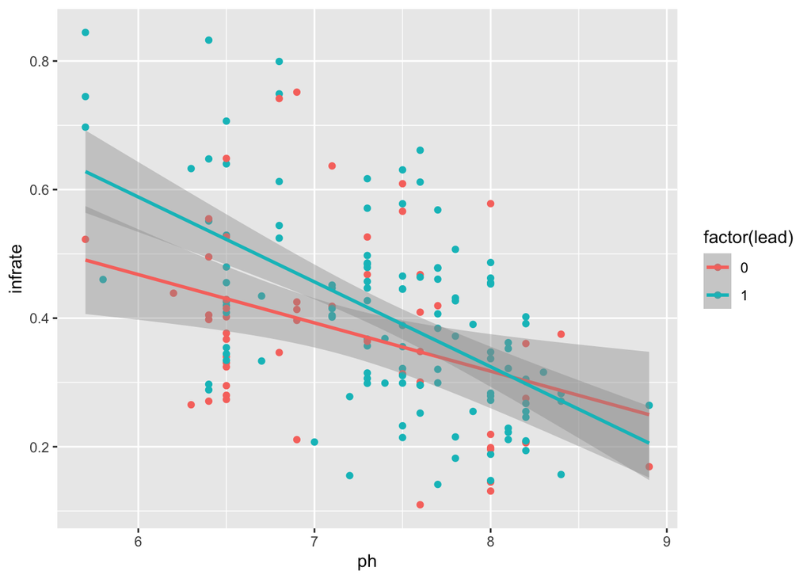

```r
# write your code in this chunk
ggplot(data = lead, aes(x=ph, y=infrate, color=factor(lead)))+
  geom_point()+
  geom_smooth(method="lm")
```

### Part F

Do the two regression lines have the same intercept? The same slope? Use the original regression in part D to test these possibilities.

The regressions have both different slopes and intercepts as apparent by the graph.

```r
# write your code in this chunk
```

### Part G

Take your regression equation from part D and rewrite it as two separate regression equations (one for no lead and one for lead). Interpret the coefficients for each.

$$\widehat{InfantMortalityRate}_{NoLead}=.9189-0.07518ph$$

$$\widehat{InfantMortalityRate}_{Lead}=1.3807-0.13204ph$$

```r
# write your code in this chunk
```

### Part H

Double check your calculations in G are correct by running the regression in D twice, once for cities without lead pipes and once for cities with lead pipes. [Hint: `filter()` the data first, then use the filtered data for the `data=` in each regression.]

```r
# write your code here!
nolead <- lead %>%
  filter(lead==0)

wlead <- lead %>%
  filter(lead==1)

noleadreg <- lm(data = nolead, infrate ~ ph)
noleadreg %>%
  summary()
```

```
Call:
lm(formula = infrate ~ ph, data = nolead)

Residuals:
     Min       1Q   Median       3Q      Max
-0.23779 -0.09733 -0.01506  0.07053  0.35139

Coefficients:
            Estimate Std. Error t value Pr(>|t|)
(Intercept)  0.91890    0.18543   4.955 7.77e-06 ***
ph          -0.07518    0.02579  -2.915  0.00521 **
---
Signif. codes:  0 '***' 0.001 '**' 0.01 '*' 0.05 '.' 0.1 ' ' 1

Residual standard error: 0.1385 on 53 degrees of freedom
Multiple R-squared:  0.1381,    Adjusted R-squared:  0.1219
F-statistic: 8.495 on 1 and 53 DF,  p-value: 0.005206
```

```r
wleadreg <- lm(data = wlead, infrate ~ ph)
wleadreg %>%
  summary()
```

```
Call:
lm(formula = infrate ~ ph, data = wlead)

Residuals:
     Min       1Q   Median       3Q      Max
-0.27492 -0.08881  0.00664  0.08059  0.31646

Coefficients:
            Estimate Std. Error t value Pr(>|t|)
(Intercept)  1.38070    0.13189   10.47  < 2e-16 ***
ph          -0.13204    0.01775   -7.44 1.97e-11 ***
---
Signif. codes:  0 '***' 0.001 '**' 0.01 '*' 0.05 '.' 0.1 ' ' 1

Residual standard error: 0.1263 on 115 degrees of freedom
Multiple R-squared:  0.325, Adjusted R-squared:  0.3191
F-statistic: 55.36 on 1 and 115 DF,  p-value: 1.967e-11
```

### Part I

Use `modelsummary` to make a nice output table of all of your regressions from parts B, C, and D.

```r
# write your code in this chunk
models <- list(
  "Part B" = first,
  "Part C" = second,
  "Part D" = third
)
modelsummary(models = models)
```

|  | Part B | Part C | Part D |
| --- | --- | --- | --- |
| (Intercept) | 0.381 | 1.178 | 0.919 |
|  | (0.020) | (0.107) | (0.174) |
| lead | 0.022 | 0.050 | 0.462 |
|  | (0.025) | (0.022) | (0.221) |
| ph |  | −0.111 | −0.075 |
|  |  | (0.015) | (0.024) |
| lead × ph |  |  | −0.057 |
|  |  |  | (0.030) |
| Num.Obs. | 172 | 172 | 172 |
| R2 | 0.005 | 0.257 | 0.272 |
| R2 Adj. | −0.001 | 0.248 | 0.259 |
| AIC | −157.3 | −205.5 | −207.0 |
| BIC | −147.8 | −192.9 | −191.3 |
| Log.Lik. | 81.638 | 106.748 | 108.521 |
| F | 0.796 | 29.181 | 20.908 |
| RMSE | 0.15 | 0.13 | 0.13 |

## Question 10

- [`freedom.csv`](http://metricsf22.classes.ryansafner.com/files/data/freedom.csv)

Let’s look at economic freedom and GDP per capita using some data I sourced from [Gapminder](https://gapminder.org/tools)[^1], [Freedom House](https://freedomhouse.org/content/freedom-world-data-and-resources)[^2] and [Fraser Institute Data](https://www.fraserinstitute.org/economic-freedom/dataset?geozone=world&year=2016&page=dataset)[^3] and cleaned up for you, with the following variables:

| Variable | Description |
| --- | --- |
| `Country` | Name of country |
| `ISO` | Code of country (good for plotting) |
| `econ_freedom` | Economic Freedom Index score (2016) from 1 (least) to 10 (most free) |
| `pol_freedom` | Political freedom index score (2018) from 1 (least) top 10 (most free) |
| `gdp_pc` | GDP per capita (2018 USD) |
| `continent` | Continent of country |

Download and read in `LeadMortality.csv` dataset. If you don’t want to download/upload it, you can read it in directly from the url by running this chunk:

```r
# run or edit this chunk
freedom <- read_csv("http://metricsf22.classes.ryansafner.com/files/data/freedom.csv")
```

### Part A

Does economic freedom affect GDP per capita? Create a scatterplot of `gdp_pc` (`Y`) against `econ_freedom` (`x`). Does the effect appear to be linear or nonlinear?

Nonlinear

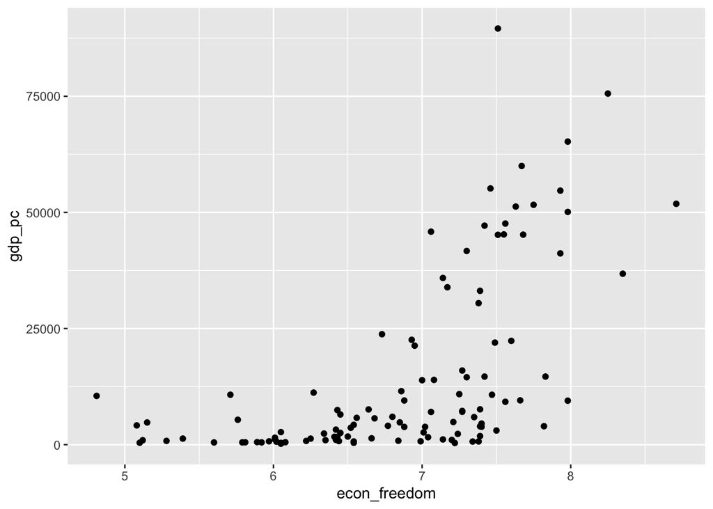

```r
# write your code in this chunk
ggplot(data = freedom)+
  aes(x=econ_freedom,
      y=gdp_pc)+
  geom_point()
```

### Part B

Run a simple regression of `gdp_pc` on `econ_freedom`. Write out the estimated regression equation. What is the marginal effect of `econ_freedom` on `gdp_pc`?

An increase in economic freedom by 1 leads to an increase in gdp per cap of 14704

```r
# write your code in this chunk
betareg <- lm(data = freedom, gdp_pc ~ econ_freedom)

betareg %>%
  summary()
```

```
Call:
lm(formula = gdp_pc ~ econ_freedom, data = freedom)

Residuals:
   Min     1Q Median     3Q    Max
-24612 -10511  -3707   9727  65562

Coefficients:
             Estimate Std. Error t value Pr(>|t|)
(Intercept)    -86400      13362  -6.466 2.85e-09 ***
econ_freedom    14704       1935   7.599 1.06e-11 ***
---
Signif. codes:  0 '***' 0.001 '**' 0.01 '*' 0.05 '.' 0.1 ' ' 1

Residual standard error: 15880 on 110 degrees of freedom
Multiple R-squared:  0.3442,    Adjusted R-squared:  0.3383
F-statistic: 57.74 on 1 and 110 DF,  p-value: 1.063e-11
```

### Part C

Add the quadratic regression line to your scatterplot. This just requires a special formula inside an additional layer: `geom_smooth(method = "lm", formula = "y ~ x + I(x^2)")`.

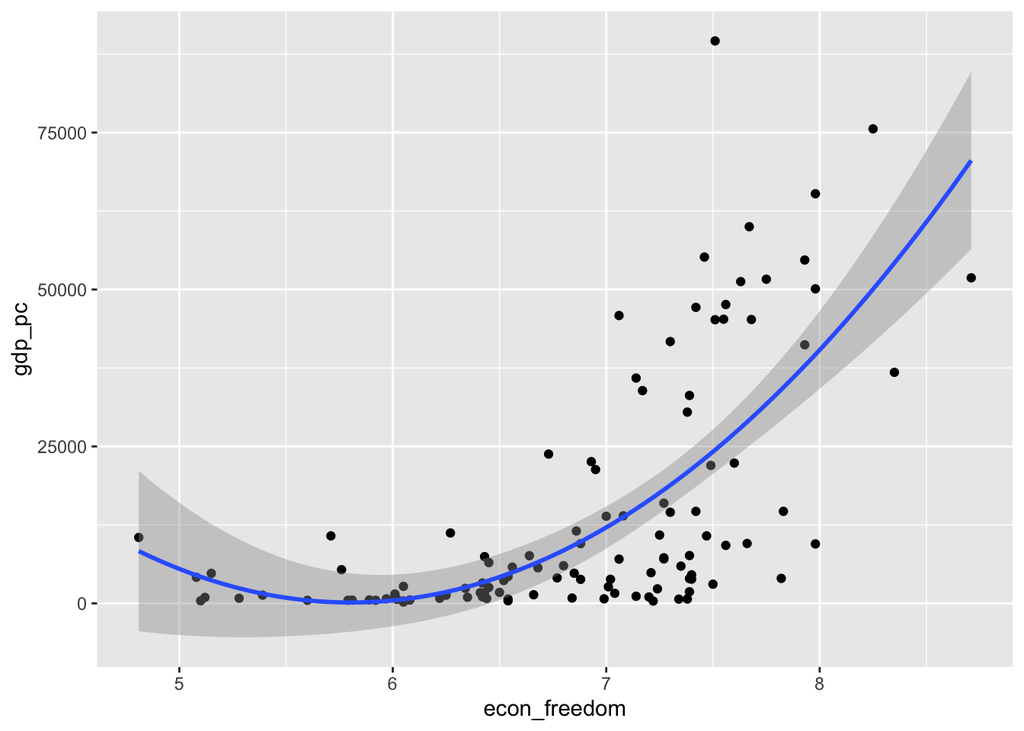

```r
# write your code here!
ggplot(data = freedom)+
  aes(x=econ_freedom,
      y=gdp_pc)+
  geom_point()+
  geom_smooth(method="lm", formula = "y ~ x + I(x^2)")
```

### Part D

What is the marginal effect of `econ_freedom` on `gdp_pc`?

```r
# write your code in this chunk
deltareg <- lm(data = freedom, gdp_pc ~ econ_freedom + I(econ_freedom^2))
deltareg %>%
  summary()
```

```
Call:
lm(formula = gdp_pc ~ econ_freedom + I(econ_freedom^2), data = freedom)

Residuals:
   Min     1Q Median     3Q    Max
-30174  -8366   -647   2980  65158

Coefficients:
                  Estimate Std. Error t value Pr(>|t|)
(Intercept)         280416      79511   3.527 0.000617 ***
econ_freedom        -96618      23908  -4.041 9.93e-05 ***
I(econ_freedom^2)     8327       1783   4.669 8.67e-06 ***
---
Signif. codes:  0 '***' 0.001 '**' 0.01 '*' 0.05 '.' 0.1 ' ' 1

Residual standard error: 14560 on 109 degrees of freedom
Multiple R-squared:  0.4535,    Adjusted R-squared:  0.4435
F-statistic: 45.23 on 2 and 109 DF,  p-value: 4.986e-15
```

### Part E

As a quadratic model, this relationship should predict an`econ_freedom` score where `gdp_pc` is at a *minimum*. What is that minimum Economic Freedom score, and what is the associated GDP per capita?

### Part F

Run a cubic model to see if we should keep going up in polynomials. Write out the estimated regression equation. Should we add a cubic term?

Probably not since it makes all coefficients statistically insignificant

```r
# write your code here!
omegareg <- lm(data = freedom, gdp_pc ~ econ_freedom + I(econ_freedom^2) + I(econ_freedom^3))
omegareg %>%
  summary()
```

```
Call:
lm(formula = gdp_pc ~ econ_freedom + I(econ_freedom^2) + I(econ_freedom^3),
    data = freedom)

Residuals:
   Min     1Q Median     3Q    Max
-30290  -8451   -493   3356  64636

Coefficients:
                   Estimate Std. Error t value Pr(>|t|)
(Intercept)        531003.4   470172.4   1.129    0.261
econ_freedom      -211572.5   213908.4  -0.989    0.325
I(econ_freedom^2)   25674.4    32127.4   0.799    0.426
I(econ_freedom^3)    -862.2     1594.2  -0.541    0.590

Residual standard error: 14610 on 108 degrees of freedom
Multiple R-squared:  0.455, Adjusted R-squared:  0.4399
F-statistic: 30.05 on 3 and 108 DF,  p-value: 3.318e-14
```

### Part G

Another way we can *test* for non-linearity is to run an $F$-test on all non-linear variables - i.e. the quadratic term and the cubic term $(\hat{\beta_2}$ and $\hat{\beta_3}$) and test against the null hypothesis that:

$$H_0: \hat{\beta_2} = \hat{\beta_3} = 0$$

Run this joint hypothesis test, and what can you conclude?

That the coefficients are statistically significant

```r
# write your code here!
linearHypothesis(omegareg, c("I(econ_freedom^2)", "I(econ_freedom^3)"))
```

```
Linear hypothesis test

Hypothesis:
I(econ_freedom^2) = 0
I(econ_freedom^3) = 0

Model 1: restricted model
Model 2: gdp_pc ~ econ_freedom + I(econ_freedom^2) + I(econ_freedom^3)

  Res.Df        RSS Df Sum of Sq      F    Pr(>F)
1    110 2.7746e+10
2    108 2.3059e+10  2 4.687e+09 10.976 4.577e-05 ***
---
Signif. codes:  0 '***' 0.001 '**' 0.01 '*' 0.05 '.' 0.1 ' ' 1
```

### Part H

Instead of a polynomial model, try out a logarithmic model. It is hard to interpret percent changes on an index, but it is easy to understand percent changes in GDP per capita, so run a *log-linear* regression. Write out the estimated regression equation. What is the marginal effect of `econ_freedom`?

```r
# write your code here!
freedom <- freedom %>%
  mutate(loggdp_pc = log(gdp_pc))

chireg <- lm(data = freedom, loggdp_pc ~ econ_freedom)
chireg %>%
  summary()
```

```
Call:
lm(formula = loggdp_pc ~ econ_freedom, data = freedom)

Residuals:
    Min      1Q  Median      3Q     Max
-3.1046 -0.9507 -0.0533  0.9021  3.3551

Coefficients:
             Estimate Std. Error t value Pr(>|t|)
(Intercept)   -0.2953     1.0323  -0.286    0.775
econ_freedom   1.2889     0.1495   8.621 5.53e-14 ***
---
Signif. codes:  0 '***' 0.001 '**' 0.01 '*' 0.05 '.' 0.1 ' ' 1

Residual standard error: 1.227 on 110 degrees of freedom
Multiple R-squared:  0.4032,    Adjusted R-squared:  0.3978
F-statistic: 74.32 on 1 and 110 DF,  p-value: 5.525e-14
```

### Part I

Make a scatterplot of your log-linear model with a regression line.

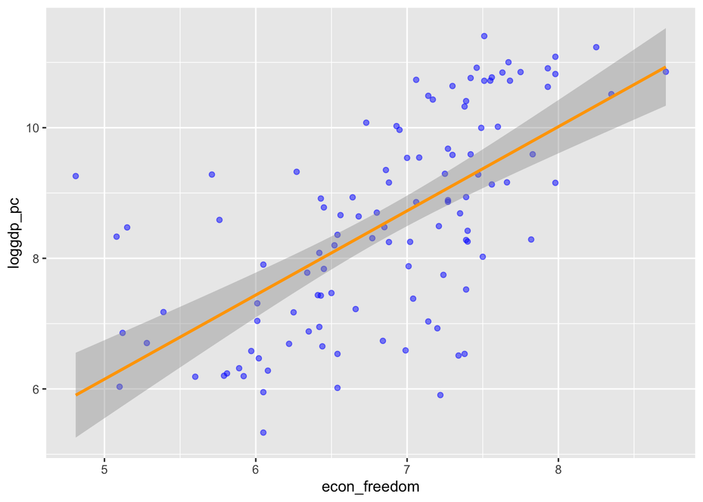

```r
# write your code here!
ggplot(data = freedom)+
  aes(x = econ_freedom,
      y = loggdp_pc)+
  geom_point(color = "blue", alpha = 0.5)+
  geom_smooth(method = "lm", color = "orange")
```

### Part J

Put all of your results together in a regression output table with `modelsummary` from your answers in questions B, C, G, and H.

```r
# write your code here!
greekmodels <- list(
  "Part B" = betareg,
  "Part D" = deltareg,
  "Part F" = omegareg,
  "Part H" = chireg
)

modelsummary(greekmodels)
```

|  | Part B | Part D | Part F | Part H |
| --- | --- | --- | --- | --- |
| (Intercept) | −86400.072 | 280416.484 | 531003.394 | −0.295 |
|  | (13361.772) | (79511.266) | (470172.382) | (1.032) |
| econ_freedom | 14704.299 | −96618.520 | −211572.478 | 1.289 |
|  | (1935.129) | (23908.057) | (213908.439) | (0.150) |
| I(econ_freedom^2) |  | 8326.609 | 25674.415 |  |
|  |  | (1783.317) | (32127.384) |  |
| I(econ_freedom^3) |  |  | −862.155 |  |
|  |  |  | (1594.196) |  |
| Num.Obs. | 112 | 112 | 112 | 112 |
| R2 | 0.344 | 0.454 | 0.455 | 0.403 |
| R2 Adj. | 0.338 | 0.443 | 0.440 | 0.398 |
| AIC | 2488.6 | 2470.1 | 2471.8 | 367.7 |
| BIC | 2496.7 | 2481.0 | 2485.4 | 375.8 |
| Log.Lik. | −1241.281 | −1231.071 | −1230.919 | −180.828 |
| F | 57.739 | 45.229 | 30.055 | 74.318 |
| RMSE | 15739.48 | 14368.05 | 14348.64 | 1.22 |

## Footnotes

[^1]: GDP per capita (2018)
[^2]: Political freedom score (2018)
[^3]: Economic Freedom score (2016)